# Test a Perceptual Phenomenon

## Background Information

In a Stroop task, participants are presented with a list of words, with each word displayed in a color of ink. The participant’s task is to say out loud the color of the ink in which the word is printed. The task has two conditions: a congruent words condition, and an incongruent words condition. In the congruent words condition, the words being displayed are color words whose names match the colors in which they are printed: for example RED, BLUE. In the incongruent words condition, the words displayed are color words whose names do not match the colors in which they are printed: for example PURPLE, ORANGE. In each case, we measure the time it takes to name the ink colors in equally-sized lists. Each participant will go through and record a time from each condition.

## Questions For Investigation

1. What is our independent variable? What is our dependent variable?
   - Independent variable = Congruent as well as Incongruent words
   - Dependent variable = Response time to name correct color
1. What is an appropriate set of hypotheses for this task? What kind of statistical test do you expect to perform? Justify your choices.
   - Ho: (μ1=μ2) Incongruent words condition does not create a longer answer time.
   - Ha: (μ1≠μ2) Incongruent words condition does create a longer answer time.
   - μ1 = In the congruent words condition for population this will be the mean time to answer correctly.
   - μ2 = In the incongruent words condition for population mean time to answer correctly.

Once we are done with the analyzing of the data I believe we will have a decent understanding of what may happen to more of the population. A two sided paired T-test would be the perfect test to run so that we can analyze the difference between the two variables.

1. Descriptive statistics regarding this dataset. Include at least one measure of central tendency and at least one measure of variability.

```python
import pandas as pd
import seaborn as sb
import matplotlib.pyplot as plt
import numpy as np

stroopdata = pd.read_csv('stroopdata.csv')
stroopdata.describe()
```

|  | Congruent | Incongruent |
| --- | --- | --- |
| count | 24.000000 | 24.000000 |
| mean | 14.051125 | 22.015917 |
| std | 3.559358 | 4.797057 |
| min | 8.630000 | 15.687000 |
| 25% | 11.895250 | 18.716750 |
| 50% | 14.356500 | 21.017500 |
| 75% | 16.200750 | 24.051500 |
| max | 22.328000 | 35.255000 |

Describe was used to easily view the mean difference between Congruent and Incongruent variables. This does show that the Congruent time mean was approx. 8 seconds shorter than the Incongruent time mean.

```python
stroopdata.skew()
```

```
Congruent      0.41690
Incongruent    1.54759
dtype: float64
```

```python
stroopdata.var()
```

```
Congruent      12.669029
Incongruent    23.011757
dtype: float64
```

Var was used to check the spread. As we can see the data is not centered around the median so it has a good spread.

```python
stroopdata.median()
```

```
Congruent      14.3565
Incongruent    21.0175
dtype: float64
```

Median was used to compare with the mean and it is very close with a 7 second difference compared to an 8 second difference using the mean.

```python
stroopdata.corr()
```

|  | Congruent | Incongruent |
| --- | --- | --- |
| Congruent | 1.00000 | 0.35182 |
| Incongruent | 0.35182 | 1.00000 |

```python
stroopdata.cov()
```

|  | Congruent | Incongruent |
| --- | --- | --- |
| Congruent | 12.669029 | 6.007123 |
| Incongruent | 6.007123 | 23.011757 |

Cov was used to view how the two variabled varied with each other.

1. Provide one or two visualizations that show the distribution of the sample data. Write one or two sentences noting what you observe about the plot or plots.

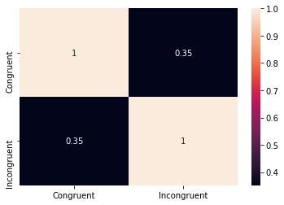

```python
df = pd.DataFrame(stroopdata,columns=['Congruent','Incongruent'])

corrMatrix = df.corr()
sb.heatmap(corrMatrix, annot=True)
plt.show()
```

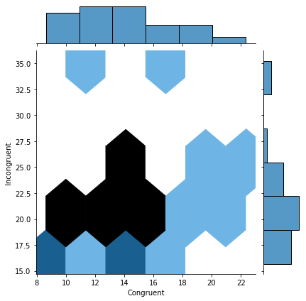

```python
p = sb.jointplot(data=df,x='Congruent', y='Incongruent',kind='hex')
```

This joint plot shows us another image with Congruent and Incongruent times are shown with each other.

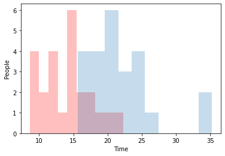

```python
plt.hist(stroopdata['Congruent'], color='red', alpha=.25)
plt.hist(stroopdata['Incongruent'], alpha=.25)
plt.xlabel('Time')
plt.ylabel('People')
```

This graph shows a connection with Congruent and Incongruent variables and the time it takes to correctly answer the color. There are two outliers in the 34/35 second range on the graph.

```python
from scipy import stats
stats.ttest_rel(stroopdata.Congruent, stroopdata.Incongruent)
```

```
Ttest_relResult(statistic=-8.020706944109957, pvalue=4.103000585711178e-08)
```